# denim DSL

```r
library(denim)
```

## Model definition in denim

In denim, model is defined by a set of transitions between compartments. Each transition is provided in the form of a *key-value* pair, where:

- *key* show the transition direction between 2 compartments.
- *value* is an expression that describe the transition, either as a rate given by a *math expression* or as a distribution of dwell-time in the origin compartment. This distribution can be specified parametrically using the *built-in distribution function* or through providing of *histogram numeric values*.

These *key-value* pairs can be provided in 2 ways

- Using denim domain-specific language (DSL).
- Define as a `list` in R.

## Denim DSL

In denim, each line of code must be a transition. The syntax for defining a transition in denim DSL is as followed:

`from -> to = [transition]`

Model definition written in denim DSL must be parsed by the function `denim_dsl()`

*Math expression*

For math expression, some basic supported operators include: `+` for addition, `-` for minus, `*` for multiplication, `/` for division, `^` for power. The users can also define additional model parameters in the math expression.

Math expressions in denim are parsed using muparser. For a full list of operators, visit the muparser website at https://beltoforion.de/en/muparser/features.php.

*Distribution functions*

Several built-in functions are provided to describe transitions based on the distribution of dwell time:

- For parametric distributions: `d_lognormal()`, `d_gamma()`, `d_weibull()`, `d_exponential()`
- For non-parametric distributions: `nonparametric()`

Each of these functions accepts either fixed numerical values or model parameters as inputs for their distributional parameters.

### Define a classic SIR model

A classic SIR model can be defined in denim as followed

```r
sir_model <- denim_dsl({
  S -> I = beta * (I/N) * S
  I -> R = d_exponential(rate = gamma)
})
```

`denim_dsl()` parses the given expression and return an R `list` as followed.

```r
sir_model
```

```
#> $`S -> I`
#> [1] "beta * (I/N) * S"
#>
#> $`I -> R`
#> Discretized exponential distribution
#> Rate = gamma
#>
#> attr(,"class")
#> [1] "denim_transition"
```

In this example, model parameters are: `N`, `beta`, `gamma`.

Users can also choose to provide fixed values as the distributional parameter as followed.

```r
sir_model <- denim_dsl({
  S -> I = beta*(I/N)*S
  I -> R = d_exponential(rate = 1/4)
})
```

Similar to R, the users can also add comments in denim DSL by starting the comment with `#` sign.

```r
sir_model <- denim_dsl({
  # this is a comment
  S -> I = beta*(I/N)*S
  I -> R = d_exponential(rate = 1/4) # this is another comment
})
```

*Run model*

To run the model, the users must provide:

- Values for model parameters (in this example, `N`, `beta`, and `gamma`).
- Initial population for the compartments.
- Simulation configurations.

Parameters and initial values can be defined as named vectors or named lists in R.

```r
# parameters for the model
parameters <- c(
  beta = 0.4,
  N = 1000,
  gamma = 1/7
)
# initial population for each compartment
initValues <- c(
  S = 999,
  I = 50,
  R = 0
)
```

Simulation configurations are provided as parameters for `sim()` function which runs the model, where:

- `timeStep` is the duration of each time step in the model.
- `simulationDuration` is the duration to run the simulation.

```r
mod <- sim(sir_model,
    parameters = parameters,
    initialValues = initValues,
    timeStep = 0.01,
    simulationDuration = 40)
```

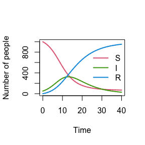

```r
plot(mod, ylim = c(1, 1000))
```

### Time varying transition

variable `time` is a special variable in denim for time varying transition (e.g. for modeling seasonality). Note that this variable can ONLY be used within math expression.

Example: time varying transition

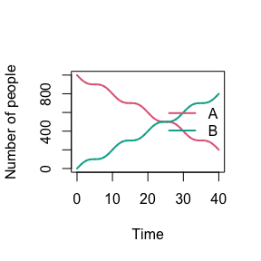

```r
time_varying_mod <- denim_dsl({
  A -> B = 20 * (1+cos(omega * time))
})

# parameters for the model
parameters <- c(
  omega = 2*pi/10
)
# initial population for each compartment
initValues <- c(A = 1000, B = 0)

mod <- sim(time_varying_mod,
    parameters = parameters,
    initialValues = initValues,
    timeStep = 0.01,
    simulationDuration = 40)

plot(mod, ylim = c(0, 1000))
```

## R list

Users can define the model structure directly as a list in R. For example, the SIR model from previous example can be represented as followed.

```r
sir_model_list <- list(
  "S -> I" = "beta * (I/N) * S",
  "I -> R" = d_exponential(rate = "gamma")
)

sir_model_list
```

```
#> $`S -> I`
#> [1] "beta * (I/N) * S"
#>
#> $`I -> R`
#> Discretized exponential distribution
#> Rate = gamma
```

Note that the transitions (`S -> I`, `I -> R`), mathematical expression (`beta * (I/N) * S`), and the model parameter (`gamma`) must now be provided as strings.

We can then run the model in the same manner as previously demonstrated.

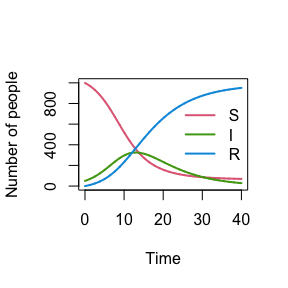

```r
# parameters for the model
parameters <- c(
  beta = 0.4,
  N = 1000,
  gamma = 1/7
)
# initial population for each compartment
initValues <- c(
  S = 999,
  I = 50,
  R = 0
)
# run the simulation
mod <- sim(sir_model_list,
    parameters = parameters,
    initialValues = initValues,
    timeStep = 0.01,
    simulationDuration = 40)
# plot output
plot(mod, ylim = c(1, 1000))
```

*When should I define model as a list in R?*

While denim DSL offers cleaner and more readable syntax to define model structure, using R list may be more familiar to R users and better suited for integration to a more R-centric workflow.

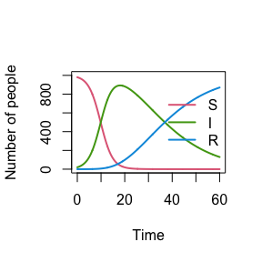

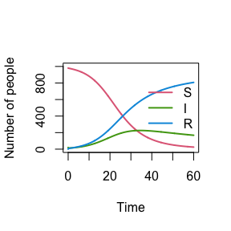

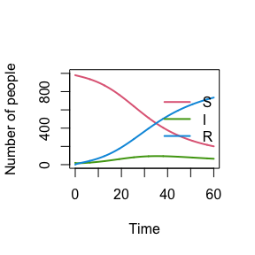

```r
library(tidyverse)
# configurations for 3 different I->R transitions
model_config <- tibble(
  IR_dists = c(d_gamma, d_weibull, d_lognormal),
  IR_pars = list(c(rate = 0.1, shape = 3), c(scale = 5, shape = 0.3), c(mu = 0.3, sigma = 2))
)

walk2(
  model_config$IR_dists, model_config$IR_pars, \(dist, par){
    transitions <- list(
      "S -> I" = "beta * S * (I / N)",
      # This is not applicable when using denim_dsl()
      "I -> R" = do.call(dist, as.list(par))
    )

    # model settings
    denimInitialValues <- c(S = 980, I = 20, R = 0)
    parameters <- c(
      beta = 0.4,
      N = 1000
    )

    # compare output
    mod <- sim(transitions = transitions,
               initialValues = denimInitialValues,
               parameters = parameters,
               simulationDuration = 60,
               timeStep = 0.05)

    plot(mod, ylim = c(0,1000))
})
```